# Week 5 - Cleaning and Reformatting Data for Visualization

Alex Dragonetti

2-25-2024

# 1 Overview

We have been tasked with cleaning and reorganizing exisiting data sets. The four data sets each contain different data related to life expectancy in different countries.

3 of the 4 data sets are organized in a ‘wide’ format. For example, the ‘income’ data set has 220 columns. Column 1 is the country of interest, and each subsequent column is a year, from 1800-2018 (inclusive). Each year variable starts with a capital ‘X’.

# 2 Cleaning and Re-formatting the Data

We will first condense those 3 data sets to a data set with 3 columns. This will allow an easier merge. In the process of doing this, we will remove the “X” from the start of each year

```r
ipp.long <- ipp %>%
  pivot_longer(cols = starts_with("X"), names_to = "year", values_to = "income") %>%
  mutate(year = as.numeric(str_remove(year, "^X")))

ley.long <- ley %>%
  pivot_longer(cols = starts_with("X"), names_to = "year", values_to = "lifeExp") %>%
  mutate(year = as.numeric(str_remove(year, "^X")))

pop.long <- pop %>%
  pivot_longer(cols = starts_with("X"), names_to = "year", values_to = "population") %>%
  mutate(year = as.numeric(str_remove(year, "^X")))
```

We have been asked to create a dataset called `LifeExpIncom` that only contains Life Expectancy and Income. The requested format is lower case for all variables except for ‘lifeExp’ for life expectancy.

We will also merge the remaining data into one set. The final data sets will replace ‘geo’ with ‘country’, per request of our assignment.

```r
LifeExpIncom <- merge(ipp.long, ley.long, by = c("geo", "year"))

merge.df.1 <- merge(LifeExpIncom, pop.long, by = c("geo", "year"))

colnames(cr)[1]<-"geo"
merge.df.2 <-merge(merge.df.1, cr, by = "geo")

colnames(LifeExpIncom)[1]<-"country"
colnames(merge.df.2)[1]<-"country"

#write.csv(merge.df.2, "C:\\Users\\Alex\\Documents\\R\\Grad\\553\\datasets\\wk5.csv")
```

Our data is now in one dataset, ready for visualization. A copy of this data can be found at https://raw.githubusercontent.com/AlexDragonetti/STA553/main/hw5/wk5.csv

# 3 Subsetting the Data to Analyze the Year 2000

We have been asked to create a dataset for the year 2000 and visualize it. First, we must create the data:

```r
"2000data"<-subset(merge.df.2, year==2000)
#for some reason, R encounters an error while viewing "2000data", so I have created a second df that is identical
twothousanddata<-subset(merge.df.2, year==2000)

#write.csv(twothousanddata, "C:\\Users\\Alex\\Documents\\R\\Grad\\553\\datasets\\2000data.csv")
```

A copy of the above data can be found at https://raw.githubusercontent.com/AlexDragonetti/STA553/main/hw5/2000data.csv

# 4 Visualizing the Data for the year 2000

We have been asked to visually represent data from all four sets in one graph, and specifically asked to represent region with a color-code. Population size being represented with point size seems logical, meaning our graph will have income on the X axis and Life Expectancy on the Y axis.

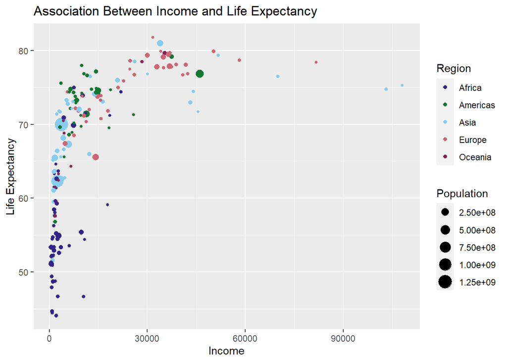

```r
life.exp.plot<-ggplot(twothousanddata, aes (x=income, y=lifeExp, color=region, size=population))+geom_point()+scale_color_manual(values=c("#332288", "#117733", "#88CCEE", "#CC6677", "#882255"))+
  labs(
  x="Income",
  y="Life Expectancy",
  size="Population",
  color="Region",
  title="Association Between Income and Life Expectancy")

life.exp.plot
```

As this is only an analysis of one year, we would suggest analyzing the relationship between income, population size, and life expectancy across multiple years of interest to see if or how this relationship changes, or what it averages to over an era of interest.